# Optimization

Groundhog Day: data science edition

In the introduction to classification, as well as in this app’s User Guide and tutorials, there have been several mentions to *finding optimal solutions*, *iterative algorithms*, and *algorithms with a stochastic component*. Here, let’s try to shine some light into what those expressions mean and how do this processes work.

## 1: Scoring functions

When designing an algorithm to perform a task one of the initial concerns will be estimating if the task was done correctly. For instance, if our task were to align DNA sequences, the simplest approach would be counting the number of matches:

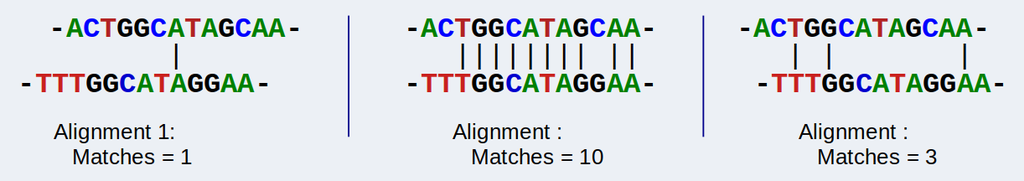

In this example above, we could formulate the quality of an alignment as *ƒ(x) = Σ( a<sub>i</sub> = b<sub>i</sub>)*, with *i* being each position in the alignment. In other instances we will measure the performance of an algorithm the other way around, by quantifying the errors in a result.

In our example on DNA sequence alignment we could also account for insertions and deletions, since this two phenomena are widely known and our sequence alignment algorithm would be quite useless without them:

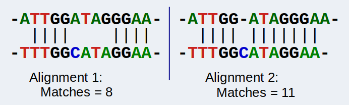

As we know more about the question at hand, and as the need for precise solutions increases, the more complex the formulas to measure performance will become. Following our alignment case, if we design an algorithm that can model insertions or deletions, *how do we score that?*.

**How do we limit the use of insertions and deletions?** If we do not implement any penalizations, the algorithm will overwhelmingly return solutions with gaps that could be meaningless to our question, since small mutations are expected more frequently than an abundance of indel events:  
In this example, if our *scoring function* only considered matching nucleotides, the solution given would be #2, but adding a gap penalty, the first result becomes the top score.

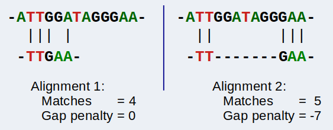

We could design multiple ways to evaluate our algorithms depending on the phenomena we’re modeling and what aspects of it we’re interested in: adapting a machine learning algorithm to our data, minimizing costs of a process, minimizing risks on a diagnostic protocol… what all of them have in common is that we can define the problem using one or several mathematical functions (broadly known as target functions) and look for the values that maximize or minimize the value of that function

## 2: So little time, so many possibilities

Once we have established a performance measurement, our **scoring function**, its time to take a look at how algorithms will choose what possible solutions to evaluate.

If our problem is simple enough, and the range of solutions is limited, we can take an exhaustive approach and try every possibility:

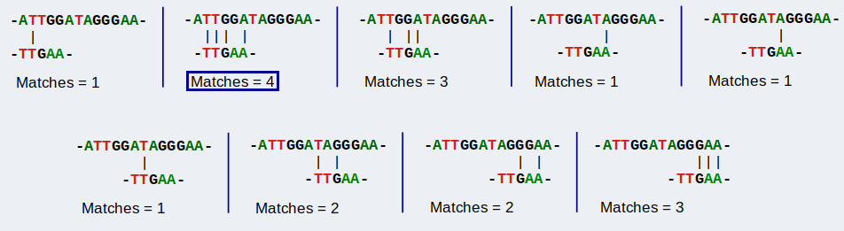

But more often than not, the problems we are trying to solve will be either too complex or there will be too many possible solutions to apply an exhaustive approach in a reasonable time and with the computational resources available. This inevitably leads to a dilemma: if one can only evaluate a fraction of the possible solutions to a problem *which possibilities do I give a chance to?*.

An optimization process usually follows the steps shown below:

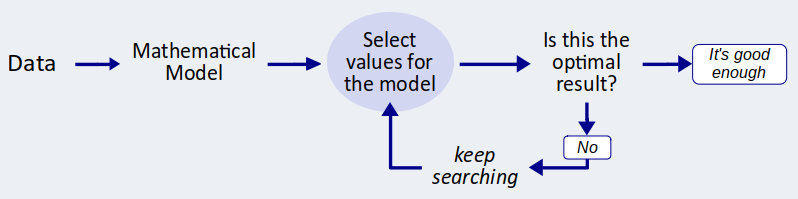

The main difference between algorithms is the strategy that each one uses to select which possibilities will be put to the test. Some strategies will be adapted specifically for a particular type of data: continuous or discrete numbers, differentiable or non-differentiable functions, categorical values, etc.

One of the most common and broad classifications of optimization algorithms is between deterministic or stochastic algorithms: * In deterministic algorithms, the rules to move from one possible solution to another are fully defined * In stochastic algorithms there can be variation from one run of the process to another. One example would be drawing possible values to test from a normal distribution: we’ll know that values close to the mean will be picked more often, but the exact number selected doesn’t have to be the same every time we run the optimization algorithm, even if we use the same data.

## 3: Deterministic algorithms

Deterministic algorithms focus on finding the global optimum of a given function. Deterministic methods guarantee that given enough time, the optimal solution will be reached and the process will be fully reproducible

An example of deterministic algorithms are those used to optimize processes defined by differentiable functions, where we can use that slope or gradient information to find local or global maximums and minimums, or points where an axis is intercepted. There are multiple ways to find and follow trends in a function, but here we will explain a simple method to find maximums or minimums in a continuous univariate and unimodal function (a function that only depends on one variable and only has one maximum and minimum), the **Golden Section Search**.

This process is based in looking for intervals that contain that extreme point, and in each iteration shrinking the interval of interest more and more, until its small enough to fit our needs:

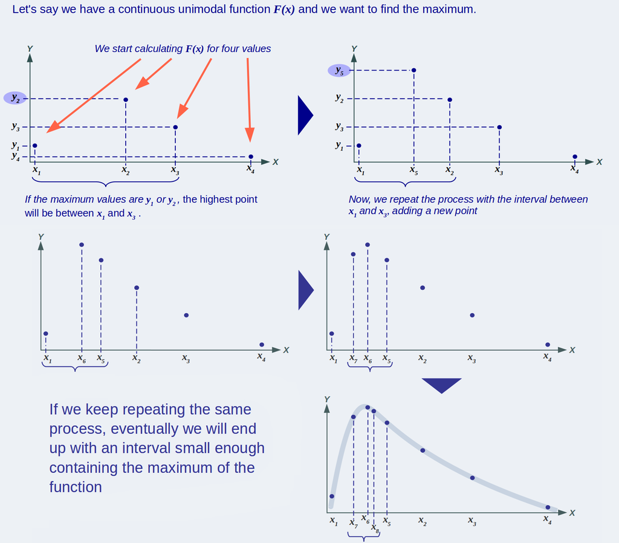

We’ll illustrate the optimization process with an example:

*Let’s say we are interested in growing cells in a bioreactor. Our starting point will be a group of cells and a new batch of medium.*  
*The manufacturer states that these cells will divide every hour in ideal conditions, but, as the cells divide, the nutrients (simplified as ‘sugar’) in the medium are consumed, up to a point where it isn’t enough easily available to sustain a growing population*.

*Our main interest would be to grow as many cells as we can without wasting resources, so we would want to know at which point the bacterial population reaches its peak growth. We could proceed through trial an error testing different growth mediums, but going in blind is often time-consuming and expensive.*  
*Thankfully, the manufacturer provides us with a mathematical model of cell growth for their strain so we could save money and time by calculating the optimal sugar concentration:*

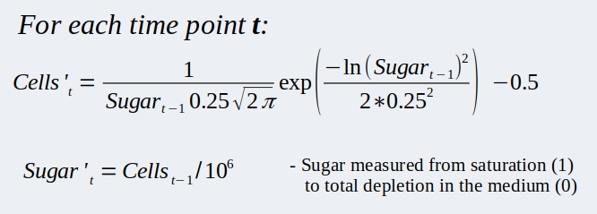